# Calculations of Fst, Rsb and xpEHH

```r
quantile.threshold.99
```

```
## both.all2   both.CA   both.CO  both.eas both.eas2  both.gpl both.gpl2   both.ID
## 0.1077280 0.4575323 0.2346230 0.3059064 0.2298768 0.2107294 0.1920340 0.3186646
##   both.IN   both.KS   both.MN   both.MT   both.ND   both.NE  both.nor both.nor2
## 0.4624174 0.2278856 0.5116294 0.3101213 0.5102449 0.3357029 0.2921918 0.2281304
##  both.pac both.pac2  both.pnw both.pnw2   both.SC   both.TX   both.WA   spr.all
## 0.3976748 0.5149802 0.1577387 0.2381695 0.6123328 0.2672842 0.2371903 0.3946323
##    spr.CA   spr.gpl    spr.ID    spr.MN    spr.ND   spr.nor  spr.nor2   spr.pac
## 0.2532840 0.3438628 0.3440463 0.3880921 0.4363932 0.3230598 0.3935414 0.2455591
##  spr.pac2   spr.pnw  spr.pnw2  spr.spr2    spr.WA   win.all    win.CO   win.eas
## 0.5408689 0.2213486 0.5200000 0.2377379 0.3038382 0.3946323 0.3975956 0.3758585
##  win.eas2   win.gpl  win.gpl2    win.ID    win.IN    win.KS    win.NE   win.nor
## 0.2343256 0.2938709 0.1977199 0.2829071 0.5560024 0.2858024 0.4128792 0.2369632
##    win.NY    win.OR   win.pnw  win.pnw2    win.SC    win.WA  win.win2
## 0.5287920 0.3952695 0.2431512 0.2145961 0.7008811 0.3550118 0.1041405
```

```r
quantile.threshold.997
```

```
## both.all2   both.CA   both.CO  both.eas both.eas2  both.gpl both.gpl2   both.ID
## 0.1320109 0.4749680 0.2991110 0.3721163 0.2700051 0.2446526 0.2306803 0.3343244
##   both.IN   both.KS   both.MN   both.MT   both.ND   both.NE  both.nor both.nor2
## 0.5695214 0.2950873 0.6402489 0.3518769 0.6230193 0.4123898 0.3609737 0.2840388
##  both.pac both.pac2  both.pnw both.pnw2   both.SC   both.TX   both.WA   spr.all
## 0.4740168 0.5517241 0.1909283 0.3018484 0.7459944 0.3491773 0.3354606 0.5218151
##    spr.CA   spr.gpl    spr.ID    spr.MN    spr.ND   spr.nor  spr.nor2   spr.pac
## 0.3189307 0.4265991 0.3935292 0.4352804 0.5714188 0.3438972 0.4283921 0.2997660
##  spr.pac2   spr.pnw  spr.pnw2  spr.spr2    spr.WA   win.all    win.CO   win.eas
## 0.5947964 0.2681771 0.6107336 0.2885722 0.4156045 0.5218151 0.5239676 0.4601219
##  win.eas2   win.gpl  win.gpl2    win.ID    win.IN    win.KS    win.NE   win.nor
## 0.2857342 0.3107859 0.2624252 0.3745772 0.5951387 0.3427710 0.5038780 0.3273574
##    win.NY    win.OR   win.pnw  win.pnw2    win.SC    win.WA  win.win2
## 0.5777443 0.4636784 0.3126246 0.2760454 0.7722903 0.4803244 0.1483302
```

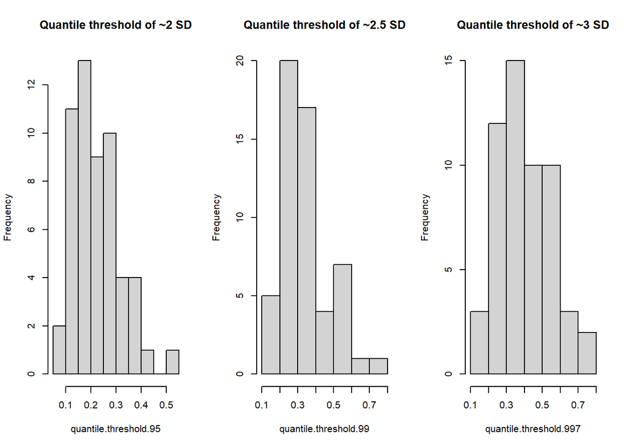

```r
par(mfrow = c(1, 3))
hist(quantile.threshold.95, main = "Quantile threshold of ~2 SD")
hist(quantile.threshold.99, main = "Quantile threshold of ~2.5 SD")
hist(quantile.threshold.997, main = "Quantile threshold of ~3 SD")
```

```r
# use PIC value to determine what direction the selection is happening in Fst.
allele.freq <- map(.x = res$allele.freq, .f = ~ mutate(.x, pic = 1 - (frq.A^2 + frq.C^2 + frq.G^2 + frq.T^2) ))
pop.pairs <- res$pop.pairs
# delta.pic <- map2(.x = pop.pairs$pop1, .y = pop.pairs$pop2, .f = ~ allele.freq[[.x]][["pic"]] - allele.freq[[.y]][["pic"]] )
# names(delta.pic) <- pop.pairs$pop1
# detla.pic will not work when frequency of A/C goes from 0.99/0.01 to 0.01/0.99 because the PIC will remain same.
# Fst value is a measure of differentiation, which can be great when frequency of A/C goes from 0.7/0.3 to 0.3/0.7. This would mean the PIC will remain the same.
# For selection in our context, we want high Fst value combined with low diversity in target population. Since Rsb and xpEHH are effective at 0.7-0.9 allele frequency, for Fst, we will require allele frequency to be 0.9:0.1, which is less or equal to a PIC of 0.18
fst.mod <- map2(.x = fst, .y = names(fst),
                .f = ~ cbind(.x, allele.freq[[.y]]["pic"]) %>%
                  mutate(., FST.MOD = ifelse(pic < 0.18, FST, NA)))
# modifies the fst so that we only consider selection in the target population
cr.fst <- map(.x = names(fst.mod), # if you want to scan all pops, use rsb
              .f = ~ calc_candidate_regions(scan = data.frame(CHR = fst.mod[[.x]][["CHR"]],
                                                              POSITION = fst.mod[[.x]][["POSITION"]],
                                                              RSB = fst.mod[[.x]][["FST.MOD"]]),
                                            # the input for calc_candidate_regions needs to be a data.frame and needs to have a column named IHS, RSB, or XPEHH. If such a column is not found, it uses the third column, but generates warning messages in the console. Hence, I just renamed the column to RSB within this map function to avoid the warning messages.
                                            threshold = quantile.threshold.95[[.x]],
                                            ignore_sign = FALSE,
                                            window_size = param$ws, overlap = param$ws*param$ovr,
                                            min_n_mrk = param$min.mrk,
                                            min_perc_extr_mrk = param$min.perc))
names(cr.fst) <- names(fst.mod)
rm(fst.mod)
map_dbl(.x = cr.fst, .f = ~nrow(.x)) %>% sum(.)
```

```
## [1] 72
```

```r
(num.cr <- map_dbl(.x = cr.fst, .f = ~nrow(.x)))
```

```
## both.all2   both.CA   both.CO  both.eas both.eas2  both.gpl both.gpl2   both.ID
##         0         1         1         0         1         0         2         0
##   both.IN   both.KS   both.MN   both.MT   both.ND   both.NE  both.nor both.nor2
##         0         2         0         4         3         1         0         1
##  both.pac both.pac2  both.pnw both.pnw2   both.SC   both.TX   both.WA   spr.all
##         0         4         1         0         2         3         0         1
##    spr.CA   spr.gpl    spr.ID    spr.MN    spr.ND   spr.nor  spr.nor2   spr.pac
##         1         1         0         0         2         2         2         1
##  spr.pac2   spr.pnw  spr.pnw2  spr.spr2    spr.WA   win.all    win.CO   win.eas
##         4         0         2         1         1         3         1         0
##  win.eas2   win.gpl  win.gpl2    win.ID    win.IN    win.KS    win.NE   win.nor
##         1         0         2         1         0         1         3         3
##    win.NY    win.OR   win.pnw  win.pnw2    win.SC    win.WA  win.win2
##         5         1         2         0         2         3         0
```

```r
cr.fst.df <- conv_names_to_labels(inp = cr.fst[num.cr > 0], sep = "\\.") # added this modifier as some populations did not have any candidate regions.
```

# Add SNPid, cM, other info, allele frequencies, PIC, to Rsb, xpEHH, Fst outputs

The Rsb, and xpEHH outputs include CHR and POSITION but no marker names. By adding marker names directly to these results, it will be easier to identify SNP with highest values in a candidate region to then look for patterns across population to write the discussion.

```r
g.pos <- mutate(geno$ab[1:6], chr.pos = str_c(Chrom, "_", pos)) %>% select(., SNPid, cM, chr.pos)

# update Rsb with chr and position
rsb.id <- map(.x = rsb,
            .f = ~ mutate(.x, chr.pos = str_c(CHR, "_", POSITION)) %>%
              left_join(select(g.pos, chr.pos, SNPid, cM), ., by = "chr.pos" ) %>%
              select(., -chr.pos) %>%
              select(., SNPid, cM, RSB, LOGPVALUE, everything()) )

# update Xpe with chr and position
xpe.id <- map(.x = xpe,
            .f = ~ mutate(.x, chr.pos = str_c(CHR, "_", POSITION)) %>%
              left_join(select(g.pos, chr.pos, SNPid, cM), ., by = "chr.pos" ) %>%
              select(., -chr.pos) %>%
              select(., SNPid, cM, XPEHH, LOGPVALUE, everything()) )
head(xpe$both.all2)
```

```
##          CHR POSITION FREQ_MAJ.POP1 FREQ_MIN.POP1 FREQ_MAJ.POP2 FREQ_MIN.POP2
## IWB57868  1A  1235801     0.7612732     0.2387268     0.7925532    0.20744681
## IWB34801  1A  1337255     0.8037135     0.1962865     0.8005319    0.19946809
## IWB71565  1A  1337305     0.8037135     0.1962865     0.8005319    0.19946809
## IWB12147  1A  2378109     0.6684350     0.3315650     0.6675532    0.33244681
## IWB25590  1A  2540668     0.6153846     0.3846154     0.6409574    0.35904255
## IWB50666  1A  3014878     0.9071618     0.0928382     0.9734043    0.02659574
##          XPEHH LOGPVALUE
## IWB57868    NA        NA
## IWB34801    NA        NA
## IWB71565    NA        NA
## IWB12147    NA        NA
## IWB25590    NA        NA
## IWB50666    NA        NA
```

```r
head(xpe.id$both.all2)
```

```
## # A tibble: 6 x 10
##   SNPid       cM XPEHH LOGPVALUE CHR   POSITION FREQ_MAJ.POP1 FREQ_MIN.POP1
##   <chr>    <dbl> <dbl>     <dbl> <chr>    <dbl>         <dbl>         <dbl>
## 1 IWB57868  13.7    NA        NA 1A     1235801         0.761        0.239
## 2 IWB34801  13.7    NA        NA 1A     1337255         0.804        0.196
## 3 IWB71565  13.7    NA        NA 1A     1337305         0.804        0.196
## 4 IWB12147  13.7    NA        NA 1A     2378109         0.668        0.332
## 5 IWB25590  16.7    NA        NA 1A     2540668         0.615        0.385
## 6 IWB50666  16.7    NA        NA 1A     3014878         0.907        0.0928
## # ... with 2 more variables: FREQ_MAJ.POP2 <dbl>, FREQ_MIN.POP2 <dbl>
```

```r
# update fst with chr and position
fst.id <- map(.x = fst,
            .f = ~ mutate(.x, chr.pos = str_c(CHR, "_", POSITION)) %>%
              left_join(select(g.pos, chr.pos, SNPid, cM), ., by = "chr.pos" ) %>%
              select(., -chr.pos) %>%
              select(., SNPid, cM, FST, everything()) )

# consolidate all results ----
pop.pairs <- res$pop.pairs
# calculate PIC values will allele frequencies
final <- map2(.x = pop.pairs$pop1, .y = pop.pairs$pop2,
            .f = ~ consolidate_results(pop1 = .x, pop2 = .y) )
names(final) <- pop.pairs$pop1
rm(rsb, xpe, fst, allele.freq)

# correlation between the three stats ----
# for correlation between FST and RSB/XPEHH, use the absolute values of the EHH based statistics.
cor.res <- list(fst.rsb = map_dbl(.x = final, .f = ~ cor(x = .x[["FST"]], y = .x[["RSB"]] %>% abs(), use = "pairwise.complete.obs", method = "pearson") ),
                fst.xpe = map_dbl(.x = final, .f = ~ cor(x = .x[["FST"]], y = .x[["XPEHH"]] %>% abs(), use = "pairwise.complete.obs", method = "pearson") ),
                rsb.xpe = map_dbl(.x = final, .f = ~ cor(x = .x[["RSB"]], y = .x[["XPEHH"]], use = "pairwise.complete.obs", method = "pearson") ) )
```

# Combine and preprocess candidate regions

Start this chunk by loading the raw outputs of candidate region search from the chunk above

```r
cr.rsb.df <- mutate(cr.rsb.df, Stat = "Rsb")
cr.xpe.df <- mutate(cr.xpe.df, Stat = "xpEHH")
cr.fst.df <- mutate(cr.fst.df, Stat = "Fst")

# Merge the fst, rsb and xpehh candidate regions files ----
names(cr.rsb.df)
```

```
##  [1] "CHR"           "START"         "END"           "N_MRK"
##  [5] "MEAN_MRK"      "MAX_MRK"       "N_EXTR_MRK"    "PERC_EXTR_MRK"
##  [9] "MEAN_EXTR_MRK" "Category"      "Habit"         "Pops"
## [13] "Stat"
```

```r
df <- rbind(cr.rsb.df, cr.xpe.df, cr.fst.df) %>%
  mutate(Genome = str_sub(CHR, 2, 2),
         KB = (END - START)/1000,
         POP = str_c(Pops, " (", Stat, " ",
                      sprintf("%.2f", round(MAX_MRK, digits = 2)), ", ",
                      # sprintf is to prevent R from dropping trailing zeroes
                      N_EXTR_MRK, "/", N_MRK, ")")) %>%
  # Select and order the columns
  select(., Genome, CHR, START, END, KB, POP, Stat, Category, Habit, Pops,
         N_MRK, N_EXTR_MRK, PERC_EXTR_MRK, MEAN_MRK, MAX_MRK, MEAN_EXTR_MRK) %>% # removed cM, SNP and Name
  arrange(., CHR, START, POP)
# divide physical position by a million
df <- mutate(df, START = START/1e6)
df <- mutate(df, END = END/1e6)
# add lines to add Genome (str_sub) and Percentage Extremal Markers.
table(df$Category) # total candidate regions by population
```

```
##
## both.all2   both.CA   both.CO  both.eas both.eas2  both.gpl both.gpl2   both.ID
##        26        15        26        15        19        29        14        32
##   both.IN   both.KS   both.MN   both.MT   both.ND   both.NE  both.nor both.nor2
##        19        27        28        21        26        28        21        16
##  both.pac both.pac2  both.pnw both.pnw2   both.SC   both.TX   both.WA   spr.all
##        14        19        35        23        13        42        32        31
##    spr.CA   spr.gpl    spr.ID    spr.MN    spr.ND   spr.nor  spr.nor2   spr.pac
##        24        21        20        17        26        21        10        26
##  spr.pac2   spr.pnw  spr.pnw2  spr.spr2    spr.WA   win.all    win.CO   win.eas
##        20        11        27        36        28         7        23        13
##  win.eas2   win.gpl  win.gpl2    win.ID    win.IN    win.KS    win.NE   win.nor
##        18        22        17        24        15        21        27        18
##    win.NY    win.OR   win.pnw  win.pnw2    win.SC    win.WA  win.win2
##        18        26        38        20        13        24        27
```

```r
table(cr.fst.df$Category) # total FST candidate regions by population
```

```
##
##   both.CA   both.CO both.eas2 both.gpl2   both.KS   both.MT   both.ND   both.NE
##         1         1         1         2         2         4         3         1
## both.nor2 both.pac2  both.pnw   both.SC   both.TX   spr.all    spr.CA   spr.gpl
##         1         4         1         2         3         1         1         1
##    spr.ND   spr.nor  spr.nor2   spr.pac  spr.pac2  spr.pnw2  spr.spr2    spr.WA
##         2         2         2         1         4         2         1         1
##   win.all    win.CO  win.eas2  win.gpl2    win.ID    win.KS    win.NE   win.nor
##         3         1         1         2         1         1         3         3
##    win.NY    win.OR   win.pnw    win.SC    win.WA
##         5         1         2         2         3
```

```r
table(cr.rsb.df$Category) # total RSB candidate regions by population
```

```
##
## both.all2   both.CA   both.CO  both.eas both.eas2  both.gpl both.gpl2   both.ID
##        12         8        14         8         8        16         1        15
##   both.IN   both.KS   both.MN   both.MT   both.ND   both.NE  both.nor both.nor2
##         9        12        10         7         8        13         9         4
##  both.pac both.pac2  both.pnw both.pnw2   both.SC   both.TX   both.WA   spr.all
##         8         4        17         9         6        18        14        13
##    spr.CA   spr.gpl    spr.ID    spr.MN    spr.ND   spr.nor  spr.nor2   spr.pac
##        10         8        10         7        11         9         3        14
##  spr.pac2   spr.pnw  spr.pnw2  spr.spr2    spr.WA   win.all    win.CO   win.eas
##         4         3        13        18        13         1        11         6
##  win.eas2   win.gpl  win.gpl2    win.ID    win.IN    win.KS    win.NE   win.nor
##         8        12         5        11         4         8        10         9
##    win.NY    win.OR   win.pnw  win.pnw2    win.SC    win.WA  win.win2
##         5        10        16        10         4         8        13
```

```r
table(cr.xpe.df$Category) # total xpEHH candidate regions by population
```

```
##
## both.all2   both.CA   both.CO  both.eas both.eas2  both.gpl both.gpl2   both.ID
##        14         6        11         7        10        13        11        17
##   both.IN   both.KS   both.MN   both.MT   both.ND   both.NE  both.nor both.nor2
##        10        13        18        10        15        14        12        11
##  both.pac both.pac2  both.pnw both.pnw2   both.SC   both.TX   both.WA   spr.all
##         6        11        17        14         5        21        18        17
##    spr.CA   spr.gpl    spr.ID    spr.MN    spr.ND   spr.nor  spr.nor2   spr.pac
##        13        12        10        10        13        10         5        11
##  spr.pac2   spr.pnw  spr.pnw2  spr.spr2    spr.WA   win.all    win.CO   win.eas
##        12         8        12        17        14         3        11         7
##  win.eas2   win.gpl  win.gpl2    win.ID    win.IN    win.KS    win.NE   win.nor
##         9        10        10        12        11        12        14         6
##    win.NY    win.OR   win.pnw  win.pnw2    win.SC    win.WA  win.win2
##         8        15        20        10         7        13        14
```

```r
table(df$CHR) # total candidate regions by chromosome
```

```
##
##  1A  1B  1D  2A  2B  2D  3A  3B  3D  4A  4B  5A  5B  5D  6A  6B  6D  7A  7B
## 138  35  13 116  57   7  35 154   2   5  20  82 141   2  27 316   3  29  47
```

```r
table(cr.fst.df$CHR) # total FST candidate regions by chromosome
```

```
##
## 1A 1B 1D 2A 2D 3A 3B 3D 4A 4B 5A 5B 5D 6A 6B 6D 7B
##  4  2 13  5  3  3  3  2  2  7  8  3  1  5  5  3  3
```

```r
table(cr.rsb.df$CHR) # total RSB candidate regions by chromosome
```

```
##
##  1A  1B  2A  2B  2D  3A  3B  4B  5A  5B  6A  6B  7A  7B
##  53  22  60  23   1  13  68   5  27  64  13 136   9  23
```

```r
table(cr.xpe.df$CHR) # total xpEHH candidate regions by chromosome
```

```
##
##  1A  1B  2A  2B  2D  3A  3B  4A  4B  5A  5B  5D  6A  6B  7A  7B
##  81  11  51  34   3  19  83   3   8  47  74   1   9 175  20  21
```

```r
median(df$KB)
```

```
## [1] 4500
```

```r
group_by(df, Stat) %>%
  summarise(mean = mean(KB), median = median(KB), min = min(KB), max = max(KB))
```

```
## # A tibble: 3 x 5
##   Stat   mean median   min   max
##   <chr> <dbl>  <dbl> <dbl> <dbl>
## 1 Fst   4549.   4000  2500 12500
## 2 Rsb   5200.   4500  2500 24000
## 3 xpEHH 5341.   4500  2500 24000
```

```r
cr.param <- str_c("cr-thres", param$thres,
                  "-mrk", param$min.mrk,
                  "-per", param$min.perc,
                  "-ws", param$ws/1000, "Kb",
                  "-ovr", param$ovr*100, "per")
scan_hh.param <- paste0("-pol-",  res$scan_hh.parameters$polarized.value, # paste0 converts NA to character
                        "-sgap-", res$scan_hh.parameters$scale.gap.value,
                        "-mgap-", res$scan_hh.parameters$max.gap.value,
                        "-discardBorder-", res$scan_hh.parameters$discard.integration.at.border, "-")
raw.results <- list(final = final, cr.consolidated = df, corr = cor.res,
                    quantile.threshold.95 = quantile.threshold.95, quantile.threshold.99 = quantile.threshold.99, quantile.threshold.997 = quantile.threshold.997)
saveRDS(raw.results, "output/raw_results_for_cr_search.RDS")
write_csv(df, str_c("output/cr_consolidated.csv"))
```